# bc01b

Phillip Abbott

September 19, 2019

```r
library(tidyverse)
library(tidytext)
library(tm)
library(e1071)
library(odbc)

library(NLP)
# library(openNLP)

library(odbc)

# con <- dbConnect(odbc::odbc(), .connection_string = "Driver={PostgreSQL Unicode};Server=mcfc01.c4hbjfyzingo.eu-west-2.rds.amazonaws.com;Database=mcfc01;UID=mcfcuser01;PWD=projecthack01")


 con <- dbConnect(odbc::odbc(), .connection_string = "Driver={PostgreSQL Unicode};Database=usit_alpha")
```

```sql
SELECT "Brief_Summary" ::varchar(4096),
  uui01::bigint*1000000000+uui02 AS uui,

  "CIO_Evaluation_Color" from public.business_case_alpha WHERE year=17
```

```r
# stringi::stri_length(business_cases_year_17[,1])

stringi::stri_length(business_cases_year_17[,1]) %>% max()
```

```
## [1] 2499
```

## Load the result

```r
source("pcx01.R")
load("p0.RData")
```

# exposition

? What are the most/least common words in each PCX? ? Which are the BC that are most/least representative of each PCX?

```r
fn <- function(pcx, n=5) {
  the_pcx <- p0$get_principal_component(pcx) %>% sort(TRUE)
  h0 <- the_pcx %>% head(n)
  t0 <- the_pcx %>% tail(n)
  x0 <- c(h0, t0)
  the_col <- c (rep(1,n), rep(2,n))
  x0 %>% barplot( main=paste("Princ. Comp. #", pcx) , col=the_col, cex.lab=.5)
  legend( "topright",legend= names(x0), cex=.62, fill=the_col)

}

# fn(1)
```

# A Picture of the principal components

## Principal Component #1

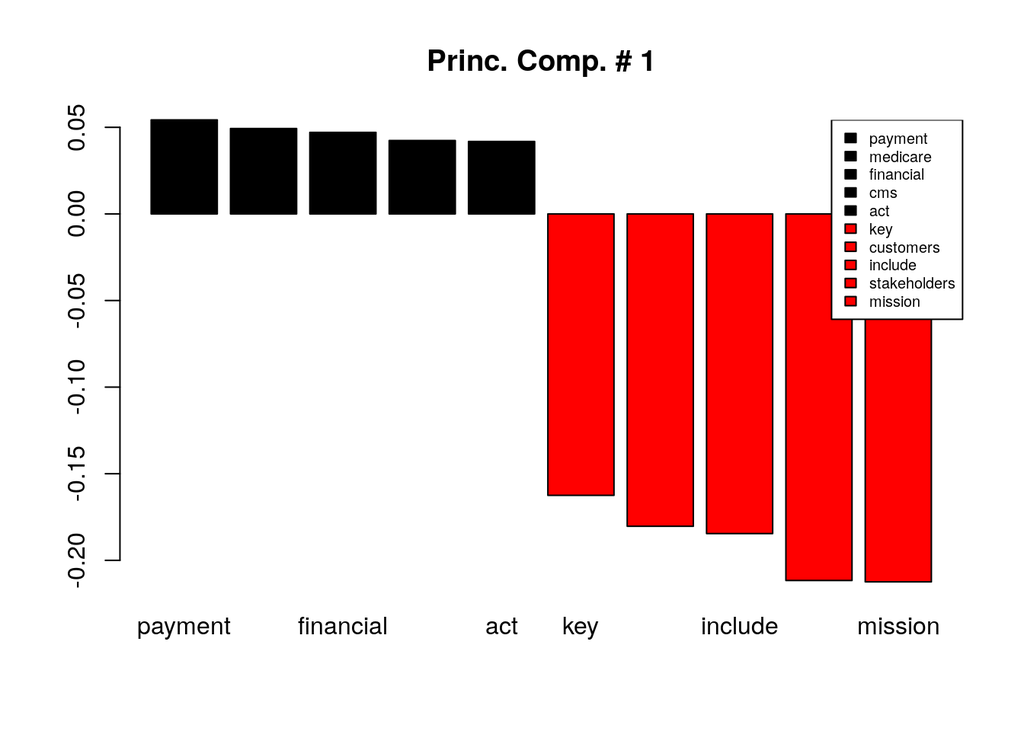

```r
fn(1)
```

## Principal Component #2

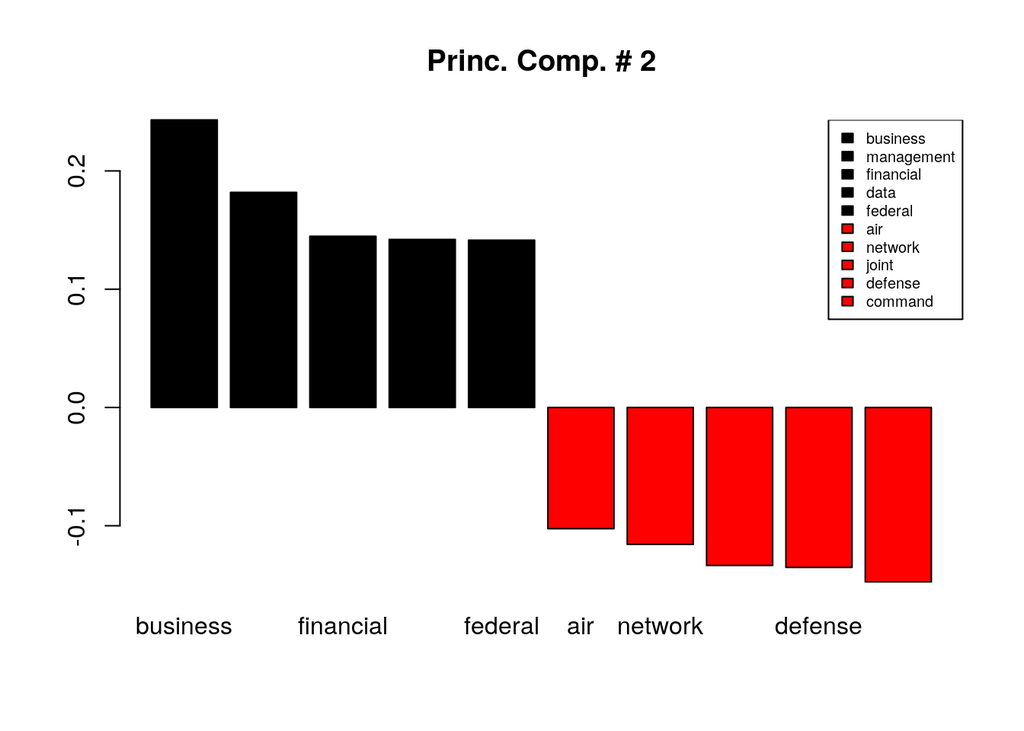

```r
fn(2)
```

## Principal Component #3

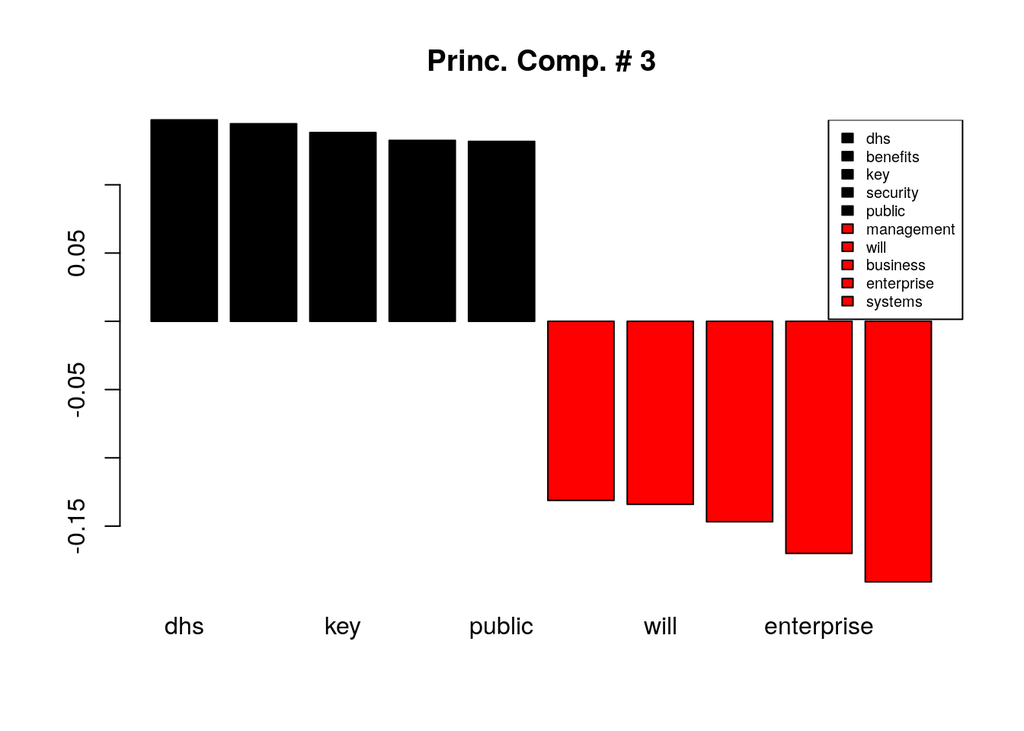

```r
fn(3)
```

## Principal Component #4

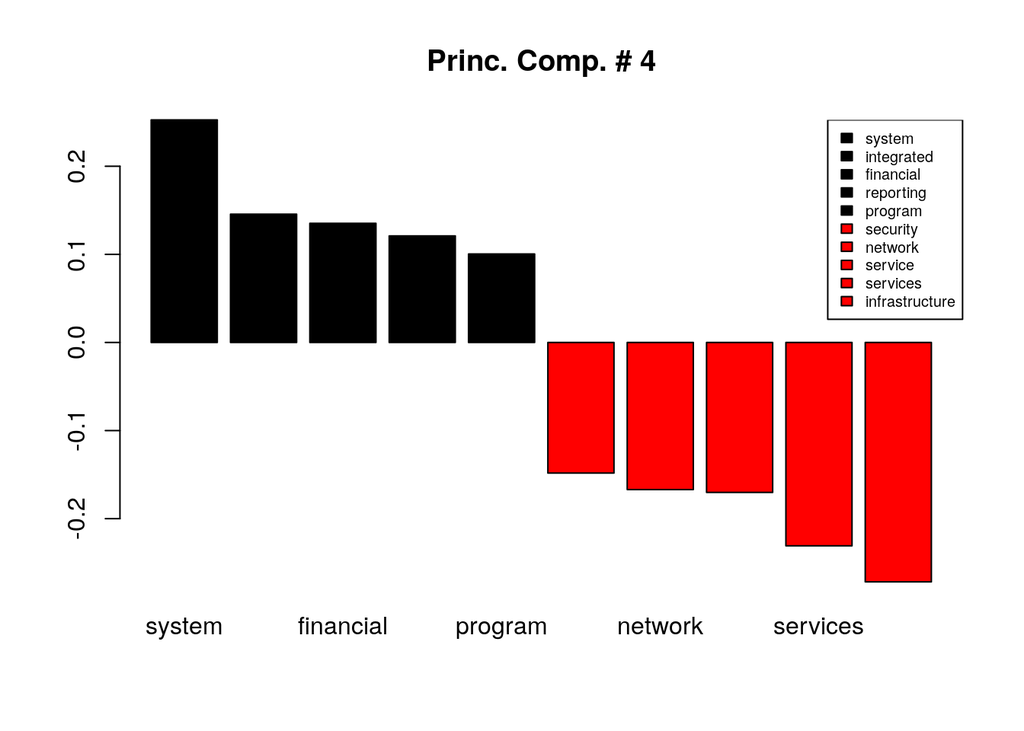

```r
fn(4)
```

## Principal Component #5

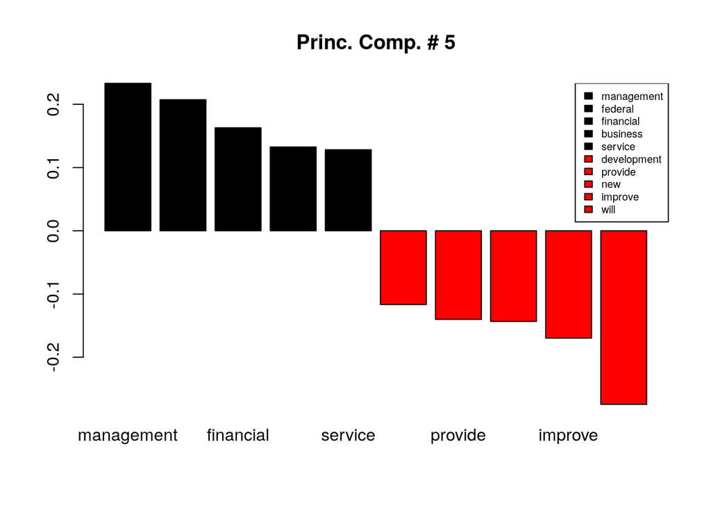

```r
fn(5)
```

## Principal Component #18

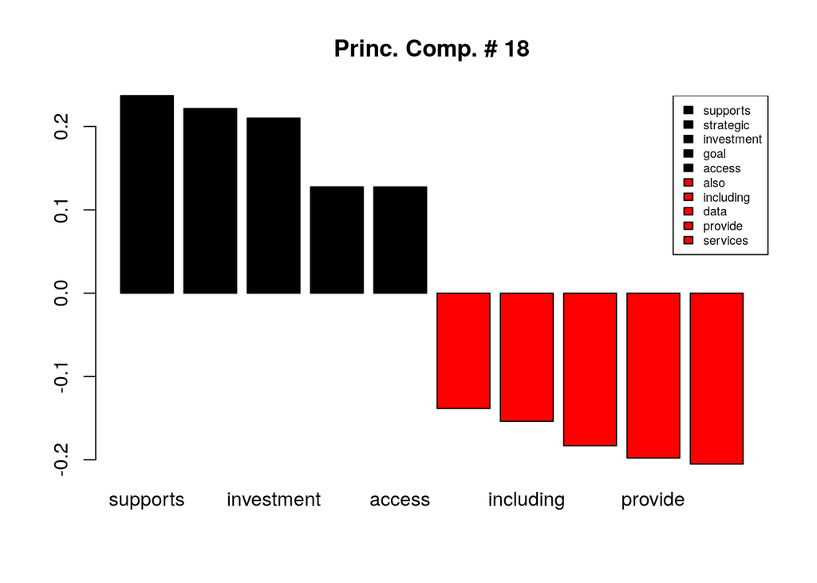

```r
fn(18)
```

# Get BC most/least representative of a given Principal Component

```r
oorder <- function(it) order(it, decreasing=TRUE)


fn2 <- function(pcx, n=5) {
  result <- new.env(emptyenv())

  the_pcx <- p0$my_projection_matrix[, (1+pcx)]
  the_order <- oorder(the_pcx)
  x0 <- p0$my_projection_matrix[the_order, c(1,(pcx+1))]
  x0 <- ( x0 %>% head(n) ) %>% rbind( x0 %>% tail(n))
  result$x0 <- x0 %>% left_join( business_cases_year_17 , by = c("idx" = "uui"))

  result$get_most_like_idx <- function(k) result$x0[k,1] %>% as.character()
  result$get_most_like_value <- function(k) result$x0[k,2]
  result$get_most_like_text <- function(k) result$x0[k,3]

  result$get_least_like_idx <- function(k) result$x0[n*2+1-k,1] %>% as.character()
  result$get_least_like_value <- function(k) result$x0[n*2+1-k,2]
  result$get_least_like_text <- function(k) result$x0[n*2+1-k,3]

  result
}

ff <- list()
for (k in 1:5) ff[[k]] <- fn2(k)

ff[[18]] <- fn2(18)

#fn2(1)
```

# Business Case descriptions most associated with Principal Component #1

## ID 9000281769 Value = 0.0279136

To measure, prevent, and correct improper payments, Medicare employs Medicare Review Contractors to request and compare the claims submitted by providers against actual medical documents. In order to identify or prevent improper payments, the Medicare Review Contractors request medical records from providers. The Electronic Submission of Medical documentation (esMD) investment affords the option to receive those medical documents electronically. Providers use a mechanism known as CONNECT gateway to electronically submit medical documentation to Recovery Auditors and other Review Contractors using NHIN technologies.

## ID 15999990254 Value = -0.1621113

BFEM is a government-off-the-shelf (GOTS) shared service application to automate the workflow processes associated with formulating budget requests and tracking performance. The system assists customer agency in the collection of budget request and performance measures, the management and tracking of budget and performance, and document generation such as the Congressional Justification and the Annual Performance Plan & Reports (APP&R).

## ID 9000281603 Value = -0.1856609

The Single Testing Contractor (STC) provides integration and regression testing for the Shared Systems functionality pertaining to claims adjudication, payments, remittance advices, Medicare Summary Notices (MSN), and various system interfaces outside of the Fiscal Intermediary Shared System (FISS), Medicare Claims System (MCS), ViPS Medicare System (VMS), and Common Working File (CWF).

## ID 9000325870 Value = -0.1886602

Interactions between medicine and industry have a wide spectrum of purposes and resulting impacts. Collaboration may promote discovery and development of new technologies that improve individual and public health. However, financial ties may create conflicts of interest in other aspects of medicine: clinical practice, clinical and basic science research, medical education, standard setting, and medical publications. Applicable manufacturers and group purchasing organizations (GPOs) must begin collection of all applicable transfers of value starting on August 1, 2013 and must report the data to CMS and attest to the data on an annual basis thereafter. After a formal data review and dispute process by the covered recipients and submission of corrections by the applicable manufacturers and GPOs, CMS must publish the data on a public website. Data must be published in a way that it is easy to use, is searchable, can be aggregated, and is downloadable. Manufacturers who produce any drugs, devices, biologicals, or medical supplies covered under Medicare, Medicaid, or the Children’s Health Insurance Program (CHIP) are subject to Open Payments reporting requirements. Except in special circumstances outlined in the Final Rule, applicable manufacturers and GPOs must disclose and attest to all applicable transactions (payments, other transfers of value, investment interests, etc.) made to any covered recipients, regardless of whether the transfer of value was related to a covered product. CMS anticipates that patients, physicians, manufacturers, GPOs, third party commercial services, the press, academic researchers, other researchers, and the general public will utilize the data collected by this program.

## ID 27000000019 Value = -0.1887047

OPM needs the supporting EPIC IT systems to continue to carry out its statutory and regulatory responsibilities for conducting background investigations of Federal staff and contractors.

# Business Case descriptions least associated with Principal Component #1

## ID 24000004053 Value = -5.6716213

Purpose and Goals: To perform its mission the United States Secret Service (USSS) relies heavily on its current Information Technology Infrastructure (ITI) and communications systems. Each day, whether executing protective, investigative or administrative duties, USSS agents, officers, administrative, technical and support staff require secure, reliable and resilient voice and data communications networks, information systems, applications, equipment and IT services to operate effectively. The goal of ITI is to provide the resources and tools that enable USSS personnel to perform these essential mission requirements.

Benefits and Contribution to Mission: ITI is the information and communication backbone of the USSS. It provides the enabling foundation for all mission-critical IT systems, supports secure sharing of information within the organization and with mission partners, and provides direct access to Law Enforcement, DoD, and other government agencies. ITI capabilities benefit and contribute to the USSS ability to efficiently and effectively plan, report and execute protective, investigative, and administrative activities, all while maintaining real-time communication interfaces with key mission partners. ITI maintains day to day operational communications as well as communication requirements that support National Security Special Events (NSSE). IT operations must ensure the network and supporting infrastructure is available 24x7x365 because of is critical importance to all USSS mission operations, NSSEs, investigations, and protection details. Further, ITI as the core IT Infrastructure for USSS, supports the DHS QHSR Mission Priority “Safeguard & Secure Cyberspace/Secure the Federal Civilian Government IT Enterprise” by making USSS data more secure from outside intrusion/attacks.

Customers, Stakeholders / Other Beneficiaries: ITI customers include all IT users at the USSS. mission partners and other beneficiaries, to include Department of Homeland Security (DHS), Department of Treasury, Department of Defense, Department of State, Executive Office of the President, law enforcement agencies (foreign, federal, state, and local), and the intelligence community.

## ID 24000005064 Value = -5.0525325

The Tactical Communications (TACCOM) Modernization investment purpose is to redesign existing Land Mobile Radio (LMR) systems, enhance/replace unsupportable legacy infrastructure, address National Telecommunications and Information Administration (NTIA) narrow-banding mandate, and anticipate future needs for increased capacity due to mandated growth in agent and officer staff while aligning with future DHS-wide wireless systems. As stated in the 2014 Quadrennial Homeland Security Review Executive Summary-Secure and Manage our Borders, “We must continue to improve upon border security -Tactical voice communication capabilities are fundamental tools that enable coordinated activities in campus and remote environments to secure the nation’s borders against illegal entry of people and goods while managing legitimate travel and trade. Investment goals-provide critical land mobile radio communication coverage; provide Advanced Encryption Standard; provide federal, state, local, tribal, territory, private sector, international law enforcement interoperability capabilities complying with NTIA P-25 mandates; modernize, replace unsupported, antiquated communication equipment. TACCOM benefits include enhanced mission safety for officers/agents protecting the U.S.-a three-fold coverage increase in previously deficient coverage areas-officer/agent radios are their lifelines; NTIA interoperability compliance affords multi-stakeholder critical situation communications; encrypted communication to prevent criminal element listening, stealing, sensitive voice traffic; upgraded digital communication equipment requiring maintenance less often reducing operational cost; and ultimately U.S. citizen protection from terrorist threat. TACCOM supports the DHS mission-Secure and Manage Our Borders. Key customers and stakeholders include over 44,000 agents and officers from CBP operational component organizations: U.S. Border Patrol, the Office of Field Operations, and the Office of Air and Marine. Other beneficiaries include the U. S. public; federal agencies such as Immigration and Customs Enforcement; Department of Interior; Department of Agriculture; Drug Enforcement Administration; Federal Bureau of Investigation; Department of Transportation; interagency partners like U.S. Coast Guard; and partnerships with state, local, tribal, territory, private sector, international law enforcement agencies to share information and conduct coordinated/integrated operations.

## ID 7000006596 Value = -5.0007154

Purpose: The Infrastructure & Operations (I&O) Division provides the overarching information technology infrastructure and support services for all Military Health System (MHS) centrally managed automated information systems.

Goal: I&O supports all MHS systems deployed in all managed health care regions worldwide. I&O provides the entire spectrum of products and services required to support infrastructure architecture design, testing, installation, upgrades, and sustainment of MHS systems worldwide, including the MHS Major Acquisition Programs, ensuring that the backbone communications and computing infrastructure is implemented and sustained on schedule, within costs, and at acceptable levels of performance to ensure mission success. This support includes providing wide area network (WAN) connectivity and circuit management, local area network (LAN) management, network protection, engineering design services, gateways, enterprise remote access to MHS systems for DoD healthcare providers, end user devices (EUDs), computing center operations, system server and storage devices, asset management sparing and repair (AMSR), end-to-end (E2E) performance measurement and monitoring, capacity planning and management; Ports, Protocols and Services (PPS), Defense Health Agency (DHA) Global Service Center (GSC) (7X24X365) help desk services), business-to-business connectivity in support of MHS business partners (e.g., Managed Care Support Contractors), DHA Network Operations Center (NOC), and Network Security Operations Center (NSOC).

Benefits include: Promotes enterprise innovation; Adopts business process solution in concert with a technical solution; Ensures information integrity and security; Establishes a consistent, integrated, aligned, agile and interoperable enterprise architecture; Reduces complexity for the end-users; Reduces time to implement functional capabilities; promotes industry standards and best practices.

The I&O Division customers are the Service members, retirees and beneficiaries who use the MHS. The activity level customers include military and dental treatment facility (MTF/DTF) commanders and their staffs that execute day-to-day operational healthcare decision-making and management. Stakeholders include Office of the Assistant Secretary of Defense (Health Affairs) (OASD (HA)), Defense Health Agency (DHA), and the senior level decision makers for the Military Medical Services.

## ID 7000002213 Value = -4.985682

Tactical Mission Command (TMC) is a suite of products and services that provide commanders and staffs executive decision making capability in a collaborative environment, planning tools and Common Operational Picture (COP) management and other maneuver functional tools. TMC satisfies requirements and capabilities identified in the Maneuver Control System (MCS) 6.4 Capability Production Document (CPD) and the Net-Enable Mission Command Capabilities Description Document (CDD) which both include Army migration to DoD net-centric environment and the Army Common Operational Environment (COE) as directed by the Command Post Computing Environment (CPCE). The overarching capability includes a user-defined COP with integrated Command and Control (C2) and Situational Awareness (SA) data and information from all Army Warfighting Functions, map-centric collaboration, Army Mission Command System and other enabling system interoperability, data management and enterprise services. The suite of products include Command Post of the Future (CPOF), Command Web, Common Tactical Vision (CTV), and Battle Command Common Services (BCCS) that provide the consolidated server and services infrastructure for systems supporting Army Mission Command from Battalion to Army Service Component Command (ASCC), Battalion and Above Joint Convergence with the Marine Corps and Web Portal for Knowledge management. The MC environment will serve as a common foundation for functionality development and support by converging onto a common architecture and infrastructure defined by the Army COE. COE will significantly enhance the ability of commanders and staff to effectively conduct collaborative mission planning and execution across a range of operations and spectrum of conflict while reducing the long term cost of the Army System of Systems (SoS) by eliminating the need for duplicative functions and redundant application development required in legacy thick client workstations.

TMC customers and beneficiaries are Army combatant and force commanders and staffs at battalion level and above, operationally deployed and in garrison environments. The stakeholders for this investment are the Program Executive Office Command, Control, and Communications-Tactical (PEO C3T) and the HQDA staff that supports this program (G3, G6, G8) as well as the Department of Defense Chief Information Officer (DoD CIO). The TRADOC Capability Manager provided a validated need statement.

## ID 24000005666 Value = -4.8947679

This investment supports the mission of the Department of Homeland Security (DHS) by providing secure, reliable IT services across the Transportation Security Administration (TSA) that includes personal computers, desktop/network and enterprise applications, system centric applications, local and wide area networks, data-hosting centers, operational support centers, help desk services, telecommunications, and information security.ITIP provides a modern, efficient, and robust IT infrastructure for the production, processing, managing, storage, protection, and communication of information. ITIP benefits TSA by allowing the organization to work more efficiently and maximize productivity. ITIP provides TSA the capability to communicate quickly and effectively.In FY14 ITIP absorbed the TSA Operating Platform (TOP) and the Federal Air Marshall Service Network (FAMSNet).TOP supports mission critical applications across TSA and maintains uninterrupted network, data, and communication, helpdesk and field services while incrementally improving the adaptability of these services that will enable them to grow and change with TSA.FAMSNet is the primary electronic data transport infrastructure for the Federal Air Marshal Service (FAMS).The FAMS primary focus is to detect, deter, and defeat terrorist or other criminal hostile acts targeting U.S. air carriers.FAMSNet provides the Information Technology infrastructure in support of the FAMS’ critical mission including operations and maintenance support, help desk support, engineering and telecommunications services.ITIP supports over 60,000 TSA customers these include the Transportation Security Officers (TSO) cadre, the Freedom Center, TSA Hosting Center in St. Louis, MO, 620 CONUS/OCONUS locations, Primary and alternate Continuity of Operations (COOP) locations, and 23 international support offices.The Key Stakeholders of this investment includes Chief Information Officer (CIO), the IT Operations directors, approximately 500 airports and Federal Security Director (FSD) offices, 23 international support sites, the TSA Command Operations Centers, TSA Headquarters, and industry.The beneficiaries are the entire agency (HQ and field), TSA employees-FAMs, TSOs, and administrative staff, TSA mission areas, and DHS components, Federal, state and local governments, airlines and other transportation operators, shipping entities, and the general traveling public.

# Business Case descriptions most associated with Principal Component #2

## ID 19000000122 Value = 4.3028767

The CF Corporate Business Systems (CBS, formerly CF iManage) investment consists of financial (STARS), budgetary (FDS), procurement (STRIPES) and personnel (CHRIS) systems. Information from these systems is supported by a data warehouse (IDW) that links common data elements from each of the Department s business systems and supports both external and internal reporting.

This investment is the Department’s enterprise resource planning solution that supports the Departmental Strategic Goal of Management and Performance to achieve improved financial and business efficiencies, integrate budget and performance, and improve financial reporting to assist in decision making.

In a multi-phase effort, front-end budget formulation and funds distribution functions will be integrated into the STARS Oracle eBusiness Suite. The first phase will implement a corporate funds distribution solution that automates, standardizes, and streamlines the processes and procedures across the Department. The second phase will implement a corporate budget formulation solution that will replace the Excel spreadsheets in use today and will allow budgets to be formulated from the bottom up across the enterprise in a standard framework. Future efforts will include development of a project cost accounting framework and system.

This investment will continue to achieve its objectives which were derived from the DOE Strategic Plan 2014-2018 and various OMB guidance: expand business process improvement services; transition from data analysis to business intelligence; and, proactively analyze, manage and control enterprise resource risks.

In addition to the Department s financial, procurement and human capital communities, Departmental leadership and external entities (OMB, Congress, auditors etc.) are consumers of this data.

Anticipated benefits include ongoing replacement of several legacy budget systems and tools, reducing mission support costs and project durations, improving resource alignment and knowledge to decision makers, providing for a leaner budget process, increasing visibility into key risk areas, and a tighter integration with the current Federal and Departmental Enterprise Architecture and maintaining the Department’s unqualified audit opinion.

## ID 16000002141 Value = 4.1724278

Disability Case Processing System (DCPS) is a Commissioner’s priority initiative to replace the 54 disparate Disability Determination (DD) components systems, support, and maintenance processes with a modern, common case-processing system. DCPS will transition the DD components from 54 fragmented, highly customized legacy systems to a common system that uses automated tools and leverages current technology. Replacing the current DD component systems with DCPS will minimize the average processing time for initial disability claims, decrease case processing-related task time and provide increased system availability to improve the overall quality of the disability determination process. This supports the agency’s strategic goal to serve the public through a stronger, more responsive disability program.

Once operational, DCPS will deliver common functionality and consistent support to each DD Component, while providing accurate, current, consistent, and accessible data. No longer maintaining multiple systems, SSA will implement software enhancements and modifications required by laws, regulations, and business rules more efficiently and consistently, and at a reduced overall cost as compared to the current legacy system environment.

DCPS will benefit SSA’s disability process functionally and technologically by providing full process integration, ease of sharing disability processing workload across DD Component sites, a common interface with other SSA offices and systems, and a dramatic reduction in the technological complexity of system support. DCPS will provide a single system that integrates the entire claims process from start to finish, including case processing, correspondence, fiscal, management information, and workload management. DCPS will use intelligent case processing to support disability examiners in making consistent decisions based on SSA Disability Policy, and leverage SSA’s investment in Intelligent Disability.

Stakeholders include: Disability Determination Components, SSA Regional Offices and SSA Field Offices, SSA Internal Components, Office of Disability Adjudication and Review, State Agencies and Programs, Disability Applicant and Representatives, Service Providers, Teleservice Center, Railroad Board, Payment Centers, and other Federal Agencies.

## ID 9000001462 Value = 4.1216486

The ACF Grants Center of Excellence (GCOE) operates GrantSolutions.gov as one of three Grants Management Line of Business (GMLOB) consortia providers approved by OMB. The GCOE provides business solutions to grants officers and specialists to process grant applications from receipt through award. Financial information is exchanged electronically with 3 agency accounting systems: HHS UFMS, DOT Delphi, and State Dept GFMS. Standards were also developed to interface with any other financial accounting system. Currently 18 different agencies, across multiple departments, have signed as business partners for GCOE services. They provide funding not only for the IT services identified in this exhibit, but also for many other business services related to Grants Management. The GCOE is undergoing a modernization effort by moving from client-server to web based architecture, along with redesigning its data architecture. ACF follows the agency’s capital programming process and related techniques to determine the GCOE’s effectiveness in supporting the HHS and ACF mission and strategic goals, and to identify and implement needed improvements. Funding for the mixed life-cycle of this project encompasses operations and maintenance of the legacy GATES system, the migration of HHS OPDIVs to the GCOE, and other improvements in support of the GMLOB, and other initiatives. The GCOE enables ACF to function as a full-fledged grants processing organization capable of supporting its expanded customer base of HHS service grant-making OPDIVs, while the NIH IMPAC II system supports research grants; these two systems comprise the HHS enterprise-wide grants management system. This investment provides for system enhancements and service delivery improvements as the various grants management and reporting processes currently in use at HHS OPDIVS continue to be unified, streamlined and standardized across the Department. This initiative is consistent with the HHS Strategic Plan goal to achieve excellence in management practices, and enhance the use of information technology in service delivery and record keeping by improving the accessibility and functionality of the technology.

## ID 27999991200 Value = 4.0369514

The HR LOB is a strategic and transformational initiative that directly supports OPM’s mission. The HR LOB actively supports the strategic goals of the OPM Strategic Plan (FY2014-2018), including Strategic Goal 4.1: Commit to an enterprise-wide IT systems strategy based on the principle that business drives strategy; Strategic Goal 4.2: Implement enabling successful practices and initiatives that strengthen IT leadership and governance; and Strategic Goal 4.4: Implement business initiatives that provide capabilities spanning the HR life cycle, allowing OPM and other Federal agencies to achieve their missions. The HR LOB also actively supports OPM and government-wide IT objectives outlined in the OPM Strategic Information Technology Plan (February 2014).

HR LOB is essential to OPM’s role to implement effective HR policies, products, and services, as the initiative drives improved HR solutions and services through the establishment of SSCs, service delivery models, and HR and HRIT strategies for agencies. HR LOB supports agencies in implementing strategic and consultative HR practices through migration of selected HR functions to SSCs consistent with the business model determined by the agency. As a government-wide initiative, the HR LOB maintains a stakeholder community of 23 Executive branch agencies and the Intelligence Community through the MAESC and through the SSCAC. OPM, OMB, and the CHCO Council established a strategic initiative to develop a single, integrated federal Human Resources Information Technology (HRIT) environment to support the 21st century federal workforce. The CHCO Council Future State Vision for HRIT seeks to provide a common user experience across the federal employee lifecycle enabled by interoperable HR systems and data.

The HR LOB Strategic Framework will enable this vision and improve HC outcomes, enhance HRIT sustainability, and increase cost savings. The Framework builds on the HR LOB s first decade of success, which delivered significant government-wide cost savings while enhancing the efficient delivery of payroll services and personnel actions through the use of shared services. When fully implemented, the Framework will result in the modernization of HRIT service delivery, the improvement of HR data management and standardization, and the effective use of strategic sourcing to drive HRIT transformation and generate $1 billion in cost savings over the next 10 years.

## ID 9000004158 Value = 3.9974064

The Bureau of Health Workforce (BHW) is responsible for managing several federal programs for placing medical professionals in underserved communities throughout the U.S., Puerto Rico, and the U.S. Virgin Islands. In an effort to streamline and modernize the processes and systems used to support their scholarship and loan repayment programs, the BHW entered into blanket purchase agreement (BPA) to provide program and project management, software development and hosting services for the BHW Management Information System Solution (BMISS) IT modernization initiative. BMISS is a custom software application designed to provide an end to end solution to manage the entire lifecycle of the BHW Scholarship and Loan Repayment Programs. In addition, BMISS includes a Shortage Designation Management System (SDMS) that tracks and manages Health Professional Shortage Areas HPSA’s) within the United States. BMISS goals and objectives are: (1) Enable better customer service; (2) Enable effective financial Management; (3) Establish a scalable and flexible technical architecture; (4) Improve Data quality and access; (5) Improve process visibility and efficiency. Through technology and process improvements it is anticipated that BHW analysts and leadership will: Be able to better respond to customer requests in an efficient and timely manner; have easy access to real time and accurate data from a central location within BMISS; have improved visibility of BHW financial information through the reporting functionality; have the ability to view and track program participant verification status; and be able to increase awareness of BHW programs by providing online tools to support outreach activities. BMISS supports the HRSA’s Strategic Goal 1: Improve Access to Quality Health Care and Services. BMISS stakeholders and customers include all 5 BHW divisions and3 BHW offices; all HRSA operating units; current and prospective scholar/loan applicants; academic and final institutions; physicians, nurses; other health care providers serving in HPSA designated service areas; the under-served/vulnerable population HRSA serves, the current Administration (ARRA funding); Congress; and NIH.

# Business Case descriptions least associated with Principal Component #2

## ID 7000004873 Value = -1.3927109

The Signal Modernization Program provides upgrades and increased capacity to the Expeditionary Signal Battalions (ESB) and Army units equipped with WIN-T Inc 1 to allow them to support combat operations, counter-insurgency operations, homeland defense, and disaster response with cellular, radio crossbanding, and internet capabilities. Program modernizes legacy terrestrial communications links and provides transport convergence for Inc 1 units, bringing Top Secret Intel, Medical, and Sustainment capabilities from their legacy stovepipe transport systems on to the WIN-T network. Additionally, provides modernization to supplement limited low bandwidth voice and chat with a wideband capability that provides effective Enroute Mission Command capability to Global Response Force (GRF), Airborne, and Joint Forcible Entry Operations.

Signal Mod customers are Army units that belong to Active, National Guard and Reserve Components, which inculde 24 ESBs and Brigade Combat Teams (BCT) and other type units.

Signal Mod stakeholders are the Army Acquisition Program Manager, WIN-T; Program Executive Officer, Command, Control and Communications (PEO C3T); Assistant Secretary of the Army for Acquisition, Logistics, and Technology (AASALT); Army G3/5/7 and Army G8.

Signal Mod beneficiaries are DoD and coalition forces.

## ID 7000001202 Value = -1.0341996

Warfighter Information Network - Tactical (WIN-T) is an incremental acquisition program that was re-structured by a Defense Acquisition Executive (DAE) Acquisition Decision Memorandum (ADM) in June 2007. WIN-T and the Joint Network Node - Network (JNN-N) were previously managed as two separate programs synchronized at the Program Executive Office (PEO) level. The ADM directed that the WIN-T Major Defense Acquisition Program absorb the former JNN-N project, and that the combined program be managed under a single COL/O6 Project Manager. The JNN-N system was originally acquired as an Urgent Procurement in 2004 in response to severe shortcomings noted in the early phases of Operation Iraqi Freedom. As a “Bridge to Future Networks”, JNN-N, now called WIN-T Increment (Inc) 1, solved the immediate need for quick-halt communications beyond line-of-sight (BLOS) for the combat arms soldiers, who are the primary beneficiaries, and enables the Army to evolve into a more modular force. It did so by integrating commercial off the shelf (COTS) and government off the shelf (GOTS) non-developmental equipment into stand alone satellite communications assemblages known as nodes. Inc 1: Networking at the Halt, consists of an updated and expanded (Ka Band added) versions of the former JNN-N systems and subsequent modifications to add capabilities such as Net Centric Waveform and Colorless Core. Inc 1 is an Acquisition Category (ACAT) ID Major Defense Acquisition Program (MDAP) governed by one overarching Acquisition Strategy with an annex that specifically addresses the Inc 1 acquisitions and, accordingly, its own set of contracts and delivery orders. Currently, Inc 1 has assembled and fielded 100% of its acqusition objective and reached its current objective of 1,860 nodes.WIN-T Increment 1 customers are the Army units that belong to Active, National Guard and Reserve components.WIN-T Increment 1 stakeholders are the Office of the Assistant Secretary of Defense for Network Information and Integration OASD(NII); the Army Acquisition Executive, Project Manager, WIN-T; Program Executive Officer, Command, Control and Communications (Tactical); Assistant Secretary of the Army for Acquisition, Logistics, and Technology ASA(ALT); Army G3; Army G8 and Force Readiness Command(FORCECOM). WIN-T Increment 1 beneficiaries are coalition forces and the DOD warfighter force.

## ID 7000006524 Value = -0.9408195

The Airborne Maritime/Fixed Station (AMF) radios are software programmable, multi-band, multi-mode, mobile ad hoc networking radios, providing simultaneous voice, data, and video communications for Army Aviation platforms. The radios will operate in networks supporting the Common Operating Picture (COP), Situational Awareness (SA), and interoperability of Mission Command (MC) systems throughout the battlefield. AMF radios will ensure the Soldier’’s ability to communicate both horizontally and vertically via voice and data within all mission areas and Common Operating Environment (COE). AMF radios will help close capability gaps by extending data networking to company and below echelons, enabling network services to the platform and connecting Army Aviation platforms to Army ground and Joint air network domains. AMF radios, employed on all Army tactical aircraft (reconnaissance, attack, cargo, and utility), will enable Aviation combat elements (Combat Aviation Brigades (CAB), Theater Aviation Brigades (TAB), and Special Operations Aviation Regiment (SOAR)), to better utilize the inherent versatility of Aviation as a complement to the unique capabilities of the other Combat Arms. Per Milestone Decision Authority (MDA) direction, the restructured AMF Program will procure radios as Non-Developmental Items (NDI). The Milestone Decision Authority (MDA), Under Secretary of Defense for Acquisition, Technology, and Logistics (USD AT&L), signed the Acquisition Program Baseline (APB) along with the Acquisition Decision Memorandum (ADM) May 2014, which identifies the Small Airborne Link 16 Terminal (SALT) and Small Airborne Networking Radio (SANR) as subprograms.

AMF will operate networking waveforms that are deployed by Joint Forces today, enable interoperability between different types of platforms, and transport operational and MC information through the tactical network. The Small Airborne Networking Radio (SANR) for the Apache, Blackhawk, Chinook, Gray Eagle and other Special Operations Forces aircraft. The SALT radio will be capable of operating Link-16 and the Soldier Radio Waveform (SRW). The SANR radio will be capable of operating the Wideband Networking Waveform (WNW), Soldier Radio Waveform (SRW), and Single Channel Ground and Airborne Radio System (SINCGARS).

## ID 7000006587 Value = -0.8112799

In FY 2013, the Joint Tactical Networking Center (JTNC) and Joint Tactical Networks (JTN) were funded in the Navy Program Element (PE) 0604280N (Joint Tactical Radio System (JTRS), Project No.3076 (formally known as JTRS Network Enterprise Domain (JNED). JNED was renamed JTN & the Joint Executive Program Office (JPEO) JTRS transitioned to the JTNC in FY 2013 in accordance with the Acquisition Decision Memorandum (ADM) dated 11 July 2012. In FY14, the program was funded in PE 0605030A, shared with JTNC.

As per the ADM dated 20 Jan 2014, JTNC became a separate entity. For FY 2015, the Army established PE 0605031 for JTN RDT&E efforts while JTNC is funded in PE 0605030. For FY16 & out, the continuing JTNC & JTN remain under separate joint budget strategies in the three Services PEs (Army 0605030A, Army 0605031A, the Navy 0605030N, and the Air Force 0605030F). As part of the joint program budget strategy, each Military Department (MILDEP) budgets for approximately 1/3 of the total program RDT&E funds. Prior to the year of execution, funding is consolidated in the Army PE for execution.

The JTNC provides the DoD centralized management, development and sustainment of joint waveform and network management applications.

JTN facilitates a competitive makeup of Non-Developmental Item (NDI), software defined radios. Key customers include Program Manager-Tactical Radios (PM-TR), PM-Mid-Tier Networking Vehicular Radio (MNVR), PM-Airborne Maritime Fixed Station (AMF), Multifunctional Information Distribution System (MIDS), DoD CIO, Program Management Warfare (PMW)-146, Training & Doctrine Command (TRADOC), Training & Doctrine Command Capability Managers for Tactical Radios (TCM-TR) & Special Operations Command (SOCOM).

Key stakeholders include: DASD(DT&E)/AT&L - C3 Cyber, NSA, Coalition, Program Executive Office Command, Control and Communications - Tactical (PEO C3T), Army Research Lab (ARL) (RDECOM), Space and Naval Warfare Systems Center (SPAWARSYSCEN) Pacific (PAC) & Atlantic (LANT), Communications-Electronics Research Development and Engineering Center (CERDEC), Digital Mobile Radio (DMR, PMW-170); as well as industry radio developers, e.g. Raytheon, Harris, Boeing, General Dynamics, Lockheed Martin, Rockwell Collins, Vulcan Wireless, VIASAT, BAE Systems, ITT, and Thales.

Beneficiaries to include: Army, Navy, Air Force, and US/NATO Coalition Forces, Software Defined Radio Programs of Record & NDI vendors.

## ID 7000007231 Value = -0.7887303

The Air Operations Center Weapon System (AOC WS), AN/USQ-163 Falconer, the senior element of the Theater Air Control System (TACS), is the weapon system the Commander, Air Force Forces (COMAFFOR) provides the Combined/Joint Force Air Component Commander (C/JFACC) for planning, executing, and assessing theater-wide air and space operations. The C/JFACC provides air, space and cyber support to the Combined/Joint Forces Commander (C/JFC) by coordinating, deconflicting and assessing the progress of various weapon systems to advance the C/JFC’’s campaign. The AOC WS develops operations strategy and planning documents. The weapon system also disseminates tasking orders; executes day-to-day peacetime and combat air, space and cyber operations; and provides rapid reaction to immediate situations by exercising positive control of friendly forces.

The AOC WS Increment 10.2 program keeps the AOC interoperable, certified, supportable, and compliant through the integration, testing and fielding of new capabilities and sustainment upgrades to the AOC WS baseline. The program supports mission requirements at Geographic and Functional AOCs, as well as Support and Manpower Augmentation units. To keep the AOC current and interoperable with the COCOMs, cyber requirements, and fifth generation weapon system/weapons, the AOC WS program plans to evolve the AOC through the integration and test of progressively improving capabilities. These activities ensure a system of systems engineering perspective for the AOC WS, and include weapon system standardization activities as defined by AOC WS requirements documents.

The primary customers are the Joint Forces Air Component Commanders (JFACCs) at each of the Combatant Commands (COCOMs). The Air Force Major Commands (MAJCOMs) as the Air Force component are the key users of this system. Air Force MAJCOM users include: Air Combat Command (ACC), Air Force Space Command (AFSPC), Air Force Special Operations Command (AFSOC), Air Mobility Command (AMC), Air National Guard (ANG), Air Force Reserve Command (AFRC), Pacific Air Force (PACAF), and United States Air Force Europe (USAFE).

# Business Case descriptions most associated with Principal Component #18

## ID 7000001017 Value = 2.088052

The purpose of the Base Information Transport Infrastructure (BITI) Wired (formerly known as Information Transport System (ITS) Increment (Inc) 1) is to install Active Duty, Reserve, and Air National Guard (ANG) base network backbone infrastructure required to meet increasing demand for high-speed network access. The goals of BITI Wired are to design, install and sustain high-speed network backbones using industry standard design methodologies and installation principles, eliminating design flaws, such as single points of failure, which occur as a result of patch-work network design and implementation. The current and anticipated benefits include providing the data, video and imagery supporting Air Force operations and providing a standard infrastructure allowing the 24th Air Force Commander to centrally manage and defend the Air Force network.

In order to accomplish the overall Air Force mission, warfighters require reliable, high speed access to combat and mission support systems. BITI Wired provides this capability by ensuring base networks have minimum required network throughput, survivability through reduced single points of failure and use of industry standard engineering practices.

BITI Wired supports base infrastructure and requires that only Joint Interoperability Test Command (JITC) Unified Capabilities (UC) Approved Product List (APL) material be purchased for installation.

The investment fully aligns with Joint Information Environment (JIE) by providing standards compliant installation level network backbones on Air Force installations as required by the warfighters to accomplish their missions. JIE is not driving new or additional base network architectural requirements, but only requires a network infrastructure to support UC.

The primary customers, stakeholders, and beneficiaries of BITI Wired are Air Force Major Commands, Direct Reporting Units, and Field Operating Agencies, Air Force Reserve and ANG, and Combatant Commands (Tenants) located on Air Force installations (United States Central Command (USCENTCOM), United States Transportation Command (USTRANSCOM), United States Northern Command (USNORTHCOM), United States Strategic Command (USSTRATCOM) and United States Special Operations Command (USSOCOM)) as well as the Defense Information Systems Agency.

## ID 9000004414 Value = 1.9536788

This investment is for the HIPAA Eligibility Transaction System (HETS 270/271). CMS is pursuing a centralized strategy for processing eligibility inquiry transactions submitted by the Medicare Part A and Part B provider community. Under this investment, CMS has developed and implemented a suite of applications that process and support Medicare eligibility requests. These suites include: HIPAA Eligibility Transaction System 270/271 (HETS 270/271), HIPAA Eligibility Transaction System Provider GUI (HPG), Trading Partner Management System (TPMS), and the Help Desk Graphical User Interface (GUI).

The purpose of the HETS 270/271 Eligibility Inquiry Transaction system is to allow authorized Trading Partners to submit HIPAA-compliant 270 ASC X12N benefit inquiry transactions electronically to CMS, and to receive electronic benefit information via HIPAA-compliant 271 ASC X12N response transactions. The Help Desk operations supporting the inquiry and response processes are intended to assist Trading Partners in submission of inquiries as well as to assist systems operation in testing and troubleshooting the inquiry processing system. The HETS 270/271 process supports Medicare claim processing by providing HIPAA-compliant beneficiary liability and eligibility information. This is required by HIPAA.

The primary users of these systems are: Institutions servicing beneficiaries in the Medicare Part A program, individuals and institutions and organizations servicing beneficiaries in the Medicare Part B program, third party entities acting on behalf of Fee For Service providers. These include billing agents, network service vendors and EDI clearing houses, and Medicare Administrative Contractors.

This investment aligns with the agencies strategic goals by helping to reduce the cost of health care by providing an access to eligibility information.

## ID 12000001025 Value = 1.6904585

EFAST2 is a shared service initiative among three agencies, the Department of Labor (DOL) Employee Benefits Security Administration (EBSA), the Internal Revenue Service (IRS), and the Pension Benefit Guaranty Corporation (PBGC).  
EFAST2 is a web-based system supporting mandated electronic filing of Form 5500 Series Annual Returns/Reports. The Employee Retirement Income Security Act of 1974 (ERISA) and provisions of the Internal Revenue Code require certain employee benefit plans (e.g., pension plans, health plans) to submit information on their size, funding, operations, and other characteristics annually to the Federal government on the Form 5500. The information collected allows EBSA to administer Titles I and III of ERISA, allows IRS to administer Titles II and III of ERISA, and allows PBGC to administer Title IV of ERISA. EFAST2 also allows these agencies to administer the Pension Protection Act (PPA). EFAST2 is the primary source of Form 5500 information used by Government regulators in enforcing ERISA, PPA and related regulations.

EFAST2 supports DOL Strategic Goal 4 to secure retirement, health, and other employee benefits and, for those not working, provide income security, and DOL Strategic Objective 4.2, “improve health benefits and retirement security for all workers” . EFAST2 supports these goals by: 1) reducing the total Form 5500 processing-cycle turnaround time from over 63 days to 1 day; 2) improving Form 5500 filing data accuracy to 100% through electronic filings and automated edit checking performed during the filing process; and 3) providing real-time access to filing status and public access to submitted filings within one day of their receipt. EFAST2 also supports DOL agency-specific (EBSA) performance goals. EFAST2 stakeholders include EBSA, IRS, PBGC, private sector users and practitioners who submit filings, plan participants who obtain EFAST2 filing data, and other government users. User Benefits: 1) reduced filer preparation time and postage cost, 2) online public access to Form 5500 data, 3) plan interest on more-quickly-restored assets; and 4) greater performance and reliability. Government Benefits: 1) lower overall operating costs compared to the legacy system; and 2) EFAST2 has a measured ROI of 124% as of November 2014. Intangible Benefits: increased level of customer support, XML standardization for Form 5500 submissions, Increased government compliance review productivity.

## ID 7000001243 Value = 1.5459325

The purpose of the Department of Defense (DoD) Teleport Generation 1/2 Technology Refresh and Technology Insertion investment is to maintain and improve the DoD Teleport Satellite Communications (SATCOM) gateways that link the deployed warfighter to the sustaining base via the Defense Information System Network (DISN). The goal of the program is to provide the warfighter with the most reliable, secure, and interoperable wideband SATCOM gateway available. Current and future activities enable global command and control of forces by giving the warfighter the latest, most reliable, worldwide satellite reachback capabilities in a flexible and cost effective manner. The DoD Teleport Technology Refresh and Technology Insertion investment continues to maintain and improve net-centric access to the DISN through the transition from legacy to Internet Protocol (IP) technology, the incorporation of robust management and control (M&C) functions, and the IP integration with legacy voice capabilities.

The DoD Teleport system’’s primary customer and beneficiary is the deployed warfighter as fielded by the Combatant Commands, Services, and defense agencies. Other customers and beneficiaries include federal and state agencies on a contingency basis. The Teleport system is part of the DISN, the portion of the Department of Defense Information Network (DoDIN) managed by the Defense Information Systems Agency (DISA). Stakeholders include the Defense Information Systems Agency, the Joint Chiefs of Staff, United States Strategic Command, all Combatant Commands, and Service Branches.

## ID 18000000121 Value = 1.4744192

EDE Suite is a free school product software suite provided by FSA to schools for their use in originating, disbursing, and packaging direct loans and grants for students. EDE Suite significantly eases the school s process of interacting with the Common Origination and Disbursement system to submit awards by automating most of the tasks involved in building the XML Common Record file that COD requires for origination and disbursement of student aid. This includes interfacing with FSA s Central Processing System to import application data in order to build shell records for students, providing a method for institutions to enter the direct loan, Pell, and TEACH award amounts for those students, and editing entered data to ensure that the final Common Record file generated by the system remains in-line with annual changes to COD submission requirements. The EDE Suite also provides valuable reconciliation functionality to participating Title IV schools, allowing them to compare their internal organizational award databases against COD s database for direct loan and grant awards, and identify discrepancies that require further attention. The overall investment in EDE Suite supports ongoing operations, maintenance, and customer support for this as well as DME support to make required annual update changes to the school software product. The EDExpress investment contributes to FSA s mission delivery via its contribution to FSA s Strategic Goals A5,B1, B3, C4, D1, E1 (http://federalstudentaid.ed.gov/static/gw/docs/FiveYearPlan_2012.pdf). Through provision of this free product, FSA significantly reduces the technical barriers to school Title IV participation, thereby contributing to ED s goal of expanding access to higher education for the nation’s learners.

# Business Case descriptions least associated with Principal Component #18

## ID 10999993100 Value = -1.8022005

The Geospatial Platform and Shared Services investment is producing an Internet-based and cloud computing-based capability that facilitates sharing of geospatial data, services, and applications by government agencies and their partners, as well as the public, to meet their mission needs. The Geospatial Platform is a government-wide shared service that delivers trusted, nationally consistent data and services; authoritative data to support informed decision-making; problem solving applications (services) that are built once and used many times across multiple Federal agencies and other organizations; and a national and federal focal point where governmental, non-governmental, private and public data and applications can be used together to inform and address national and regional issues.

Federal, state, and local government agencies collect, maintain, and use geospatial data linked to specific geographic locations in support of many functions including national security, law enforcement, health care, environmental sustainability, and emergency preparedness and response. These data are purchased or collected and maintained by many agencies independently, and their use by multiple agencies and organizations requires coordination, interoperability, and shared services and applications. The Geospatial Platform investment will provide a mechanism for the sharing of geospatial assets to reduce redundancy; ensure implementation of standards to promote integration and interoperability; establish/document oversight measures to ensure accountability; and facilitate a portfolio management approach to Federal management of National Geospatial Data Assets, fulfilling the requirements and intention of OMB Circular A-16 Supplemental Guidance.

Beneficiaries of this investment include agencies in all levels of government, which experience cost savings and avoidance; non-governmental organizations and the private sector as users of geospatial data, who find data from trusted sources, as well as compatible services, to be more readily available from a single source; and the American public, which will benefit from greater efficiency and accountability in the expenditure of tax dollars.

## ID 7000000599 Value = -1.7283546

IPPS-A will provide the Army with an integrated, multi-Component, personnel and pay system which streamlines Army Human Resources (HR), enhances the efficiency and accuracy of Army personnel and pay procedures, and supports Soldiers and their families. IPPS-A will be a web-based tool, available 24 hours a day, accessible to its customers which include Soldiers, HR professionals, Combatant Commanders, personnel and pay managers, and other authorized Army users. The primary beneficiaries are the Active Army, the Army National Guard (ARNG), and the US Army Reserve (USAR) at all installations worldwide. Additional stakeholders include the IPPS-A implementation team consisting of the Assistant Secretary of the Army, Acquisition, Logistics and Technology (ASA(ALT)), Program Executive Office Enterprise Information Systems (PEO EIS) and the Army G-1.

IPPS-A will address major deficiencies in the delivery of military personnel and pay services and provide internal controls and audit procedures that prevent incorrect payments and loss of funds. IPPS-A will support the Soldier in the core mission of conducting operations to promote and maintain effective military personnel management and ensure accurate and timely military personnel data, including the delivery of benefits, are available at all levels of management and oversight. To resolve the most critical issues, IPPS-A will combine Active Duty, ARNG, and USAR databases to integrate personnel and pay functionality, streamline and improve automated support to the mobilization and deployment processes, and implement standard data to reflect core requirements of the Combatant Commands, the Department of the Army, the Office of the Secretary of Defense (OSD) and other Federal agencies.

IPPS-A will be developed in two increments with multiple releases. Increment I will provide a trusted database with a single record for all Army Soldiers and a Soldier Record Brief (SRB). Additionally, Increment I will allow for interface communications and generation of new multi-Component reports, including a SRB for all Components. It will also lay the foundation for Increment II which will deliver fully integrated personnel and pay services for all Army Components.

## ID 10000000299 Value = -1.7197248

The Reclamation Mission Support Services (RMSS) IT Investment is comprised of IT services and resources directly supporting Reclamation’s water resource management (WRM) mission-related business objectives. RMSS is steady state, however it responds as needed to changing mission needs and technological improvements. More specifically the RMSS investment consists of approx. 80 specialized and unique applications, systems, services and the related IT resources which provide IT support to accomplish Reclamation s WRM mission. These specialized, often home grown, applications are tailored in design, support, and/or WRM function they provide. Within RMSS, the IT components (applications, systems and services) are currently being further categorized into the unique WRM business functional areas they support. (e.g. water facilities planning & operations, water resource development, water resource program management & reporting, water environmental management, etc.). All operational, maintenance and life-cycle management expenses of these mission specific RMSS IT components and services are treated as operations and maintenance (O&M) costs. Reclamation is responsible for over 75% of all constructed assets of the Water Resource Management (WRM) activity in the Dept of the Interior (DOI). Management of water resources occurs within a complex legal framework of general law and authorities currently incorporating 5,000+ pages of congressional direction. RMSS is critical to Reclamation’s mission-related WRM focused work functions that compute, store, access, maintain and back-up mission-specific data for a wide range of functional activities related to water and hydroelectric power management objectives, including planning, environmental programs, and administrative functions. To accomplish these WRM goals and objectives, Reclamation personnel need ready access to both current and historical water management data. They must analyze and summarize data, complete essential operational activities, as well as, prepare reports and presentations which provide meaningful information to citizens, business partners, and other government entities. To achieve these ends, the work force relies upon the capabilities of modern IT. RMSS is specifically tailored to support a secure, reliable data repositories, data analysis, reporting capabilities, transactions, and collaborative tools for authorized Reclamation individuals to perform their functions and work.

## ID 7000007173 Value = -1.6845089

IPPS-A will provide the Army with an integrated, multi-Component, personnel and pay system which streamlines Army Human Resources (HR), enhances the efficiency and accuracy of Army personnel and pay procedures, and supports Soldiers and their families. IPPS-A will be a web-based tool, available 24 hours a day, accessible to its customers which include Soldiers, HR professionals, Combatant Commanders, personnel and pay managers, and other authorized Army users. The primary beneficiaries are the Active Army, the Army National Guard (ARNG), and the US Army Reserve (USAR) at all installations worldwide. Additional stakeholders include the IPPS-A implementation team consisting of the Assistant Secretary of the Army, Acquisition, Logistics and Technology (ASA(ALT)), Program Executive Office Enterprise Information Systems (PEO EIS) and the Army G-1.

IPPS-A will address major deficiencies in the delivery of military personnel and pay services and provide internal controls and audit procedures that prevent incorrect payments and loss of funds. IPPS-A will support the Soldier in the core mission of conducting operations to promote and maintain effective military personnel management and ensure accurate and timely military personnel data, including the delivery of benefits, are available at all levels of management and oversight. To resolve the most critical issues, IPPS-A will combine Active Duty, ARNG, and USAR databases, integrate personnel and pay functionality, streamline and improve automated support to the mobilization and deployment processes, and implement standard data to reflect core requirements of the Combatant Commands, the Department of the Army, the Office of the Secretary of Defense (OSD) and other Federal agencies.

IPPS-A Increment II will deliver fully integrated personnel and pay services for all Army Components (Active, National Guard, and Reserve), building on the trusted database delivered by the IPPS-A Increment I program. IPPS-A Increment II will be able to link the personnel and pay functions for all Army personnel, eliminating duplicate data entry, reducing complex system maintenance, and minimizing pay discrepancies. IPPS-A Increment II will account for status changes between Active, Reserve, and National Guard components to ensure accurate service time minimizing impact on individual pay, credit for service, and other benefits as well as enable disciplined Human Resources management.

## ID 10000000363 Value = -1.5910788

iRWIn will provide a progressive and modular implementation of an end-to-end interagency wildland fire reporting capability that includes integrated and coordinated processes for collecting, reporting, and updating relevant and timely wildland fire information. Federal agencies that have management and administrative responsibility for large areas of federal land also have the legal authority to protect those lands from the adverse effects of wildfire. Wildland fires are hazardous events that threaten the safety of the general public as well as agency personnel. Wildland fires often move across or take place in multiple emergency response jurisdictions (e.g., BLM, National Park Service, Forest Service, States, Counties, Municipalities), creating a formidable challenge to coordinating the management of a wildland fire. As well, characterizing the entire fire event lifecycle in a historical context.

iRWin will reduce multiple instances of redundant data entry across wildland fire information systems. Moreover, iRWIn will promote consistency in providing updated fire data across information systems that produce or contain data related to wildland fire. iRWIn will also promote a consistent and repeatable process to gather information that describe wildland fires. This information will provide agency personnel with a consolidated view of wildland fire data, including the important context of source of the data, the timeliness of the data, how the data sources relate, and the statistical relevance of the information.

iRWIn stakeholders will primarily benefit from a consistent, repeatable, and uniform processes (and supporting systems) to collect current and historical information regarding wildland fire. Examples of wildland fire information includes: fire location; status of fire suppression operations; financial accounting and staffing statistics; resources deployed to support the operations (aircraft; personnel, fire engines, etc.); local condition information (such as topology, vegetation inventory, soil composition); situational analysis of the fire compiled from predictive models (e.g., WFDSS); and, current and historical weather conditions. Key Beneficiaries include: Fire Dispatch Personnel, Public Information Officers, Fire Incident Management Personnel, Budget and Finance Personnel, Planning and Research Personnel, Wildland Fire Executive Leadership, and most importantly the Public will be informed with accurate data.

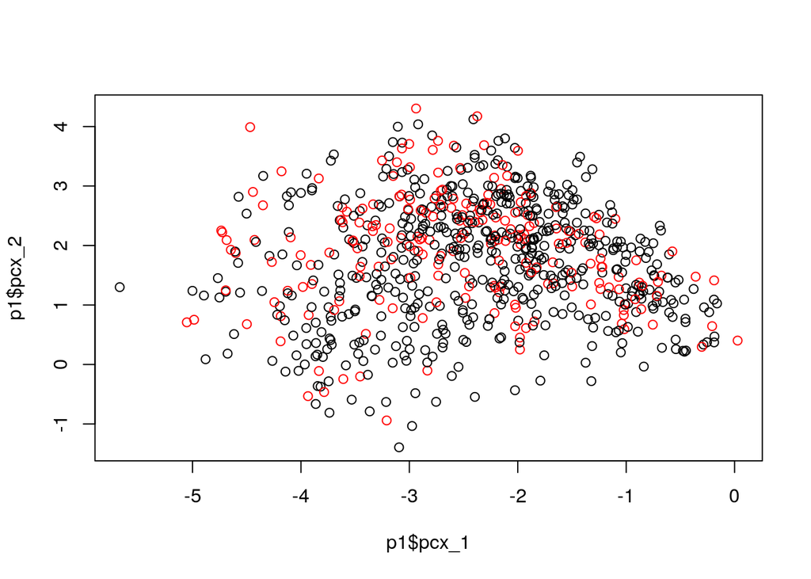

```r
the_categories <- rep(1, nrow(business_cases_year_17))
the_categories[ business_cases_year_17$CIO_Evaluation_Color=="Yellow"] <- 2
the_categories[ business_cases_year_17$CIO_Evaluation_Color=="Red"] <- 2


p1 <- p0$my_projection_matrix[,1:3] %>% cbind(the_categories)
# p1 %>% head()

# (p1$idx - p1$uui) %>% min()

plot(p1$pcx_2~p1$pcx_1, col=p1$the_categories)
```

```r
some_nice_pcx <- c(1,2,4,5, 9, 11, 18, 25, 33, 40, 48, 58, 60, 73, 76, 79, 95, 96, 97, 115, 116, 118)
p2 <- p0$my_projection_matrix[,(some_nice_pcx+1)] %>% cbind(the_categories)

p2$the_categories <- p2$the_categories  - 1

hm <- glm(the_categories~., data=p2, family=binomial)

summary(hm)
```

```
##
## Call:
## glm(formula = the_categories ~ ., family = binomial, data = p2)
##
## Deviance Residuals:
##     Min       1Q   Median       3Q      Max
## -1.5283  -0.8136  -0.6337   1.1176   2.3367
##
## Coefficients:
##             Estimate Std. Error z value Pr(>|z|)
## (Intercept) -1.78570    0.27441  -6.507 7.64e-11 ***
## pcx_1       -0.17108    0.08149  -2.099  0.03579 *
## pcx_2        0.22829    0.08680   2.630  0.00854 **
## pcx_4       -0.16439    0.09703  -1.694  0.09021 .
## pcx_5       -0.09042    0.10916  -0.828  0.40749
## pcx_9       -0.26334    0.12566  -2.096  0.03611 *
## pcx_11       0.19816    0.13362   1.483  0.13806
## pcx_18      -0.42382    0.14583  -2.906  0.00366 **
## pcx_25       0.20530    0.15101   1.359  0.17399
## pcx_33       0.22258    0.15791   1.410  0.15866
## pcx_40       0.22277    0.16403   1.358  0.17443
## pcx_48      -0.14783    0.16939  -0.873  0.38281
## pcx_58      -0.23288    0.17763  -1.311  0.18984
## pcx_60      -0.38194    0.17893  -2.135  0.03279 *
## pcx_73      -0.16516    0.18931  -0.872  0.38297
## pcx_76       0.25943    0.19118   1.357  0.17479
## pcx_79      -0.26986    0.19282  -1.400  0.16165
## pcx_95      -0.40457    0.20492  -1.974  0.04835 *
## pcx_96      -0.01034    0.20813  -0.050  0.96036
## pcx_97       0.40433    0.20833   1.941  0.05228 .
## pcx_115      0.16060    0.21838   0.735  0.46209
## pcx_116      0.14741    0.22058   0.668  0.50396
## pcx_118      0.27721    0.22130   1.253  0.21032
## ---
## Signif. codes:  0 '***' 0.001 '**' 0.01 '*' 0.05 '.' 0.1 ' ' 1
##
## (Dispersion parameter for binomial family taken to be 1)
##
##     Null deviance: 873.98  on 746  degrees of freedom
## Residual deviance: 817.05  on 724  degrees of freedom
## AIC: 863.05
##
## Number of Fisher Scoring iterations: 4
```

[output not shown]

# given pred, I should be able to get an ROC